# Act Report

- WeRateDogs is a Twitter account that rates people's dogs with a humorous comment about the dog. These ratings almost always have a denominator of 10. The numerators, though? Almost always greater than 10. 11/10, 12/10, 13/10, and more.
- After collecting the different files, assesing and cleaning them, the next logical step was to provide insights into the data.

### Highest rated dog breed.

[output not shown]

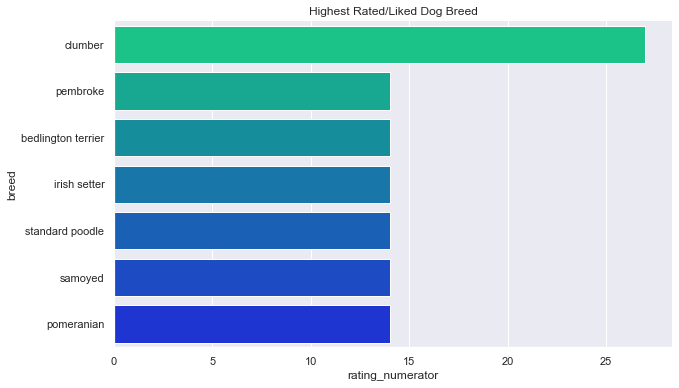

# Most popular dog name

- The dogs have been given different names and this question was to find the most popular dog names. A visualization of the data shows that the most popular dog name contained within the tweet data is Cooper and just tying at three.

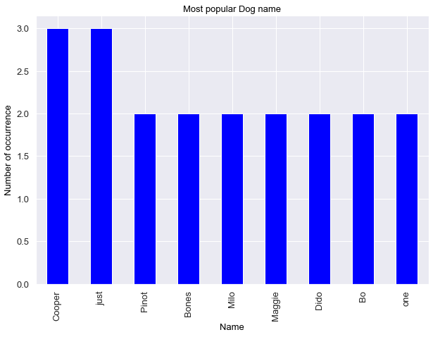

# Most used twitter source

- There were different sources used including twitter for iphone and tweet deck, but after cleaning and analysis, it was shown that most people use Twitter for Iphone.

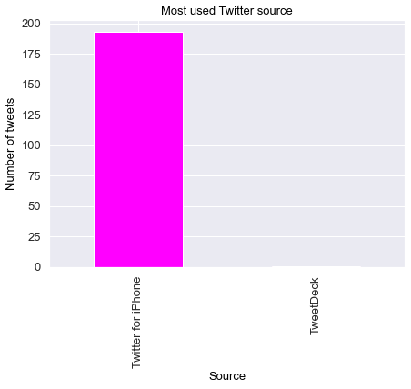

# Most popular dog stage from the retweet and favorite count.

From the data there are four dog stages: doggo, pupper, floofeer and pooper. This analysis was to show which dog stage was popular from the reteet count and fvorite count. A histogram was created and from the reult it was clear that pupper anddoggo had the lead. In each pupper and doggo were the two most popular.

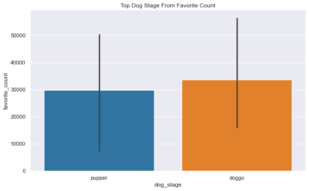

From the favorite count doggo is ahead of pupper by a larger number.

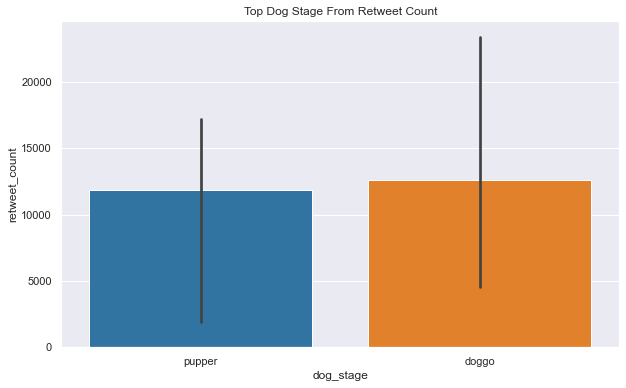